# berryFunctions

Berry Boessenkool, berry-b@gmx.de

2024-02-16

*The R package `berryFunctions`, available at [github.com/brry](https://github.com/brry/berryFunctions) and [CRAN](https://cran.r-project.org/package=berryFunctions), contains my collection of miscellaneous functions. A lot is related to plotting and hydrology (Vignette [Rmd source](https://raw.githubusercontent.com/brry/berryFunctions/master/vignettes/berryFunctions.Rmd)).*

## Package installation

```r
install.packages("berryFunctions")
library(berryFunctions)
```

To get the development version on github, including vignette:

```r
if(!requireNamespace("remotes", quitly=TRUE)) install.packages("remotes")
remotes::install_github("brry/berryFunctions", build_opts="--no-manual")
```

TOC

## Package highlights

Scatterpoints with third dimension classified into colors: `colPoints`, `colPointsLegend`, `colPointsHist`  
(This uses severall helper functions like `smallPlot`, `classify`, `logSpaced`, `pretty2`, `seqPal`)  
Write text with colored shape underneath: `textField`  
Histogram of data with logarithmic axis: `logHist`, using `logAxis`

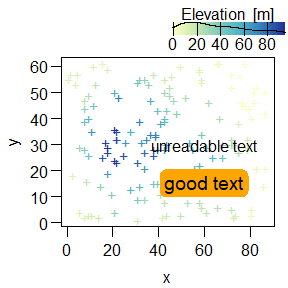

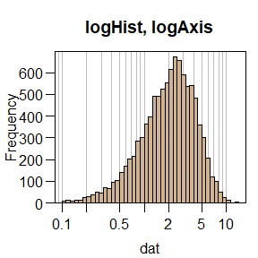

```r
x <- sample(1:87, 150, TRUE);   y <- sample(1:61, 150, TRUE);  z <- diag(volcano[x,y])-95
colPoints(x,y,z,  pch="+", legargs=list(y1=0.8,y2=1, title="Elevation  [m]"), add=FALSE)
mtext("colPoints, textField", outer=TRUE, adj=0.05, line=0.5, cex=1.2, font=2)

text(60,30, "unreadable text")
textField(60, 15, "good text", field="round", fill="orange", cex=1.2)

dat <- rbeta(1e4, 2, 80)*100; dat <- dat[dat>0.1]
logHist(dat, col="tan", breaks=50, main="logHist, logAxis")
```

Linear storage cascade (rainfall-runoff modelling): `lsc`, `unitHydrograph`, `superPos`, `nse`, `rmse`

```
##          n          k        NSE        psi
##  0.6116332 22.8333626  0.8651976  0.8651531
```

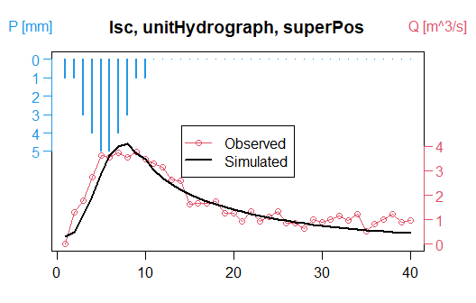

```r
# estimate parameters for Unit Hydrograph, plot data and simulation: lsc
QOBS <- dbeta(1:40/40, 3, 10) + rnorm(20,0,0.2) + c(seq(0,1,len=20), rep(1,20))
PREC <- c(1,1,3,4,5,5,4,3,1,1, rep(0,30))
lsc(PREC, QOBS, area=10, main="lsc, unitHydrograph, superPos") # , plotsim=F
```

Quick linear Regression: `linReg`  
Draw circle with given radius: `circle`  
Add transparency to existing colors: `addAlpha`  
Fit a wide range of function types to see which one is best: `mReg`

```r
a <- 1:30   ; b <- a/2.345+rnorm(30,0,3)
linReg(a,b, main="linReg, circle, addAlpha")

circle(12,3, r=5, col=addAlpha("darkgreen"), border="blue", lwd=3)

x <- c(1.3, 1.6, 2.1, 2.9, 4.4, 5.7, 6.6, 8.3, 8.6, 9.5)
y <- c(8.6, 7.9, 6.6, 5.6, 4.3, 3.7, 3.2, 2.5, 2.5, 2.2)
mReg(x,y, main="mReg")[,c(2,3,5:6)]
```

```
##               R2                              Formulas         a        b
## cubic       1.00 y = -0.02*x^3 + 0.42*x^2 - 3.2*x + 12 -0.020000  0.42043
## logarithmic 0.99               y = -7.3*log10(x) + 9.2 -7.302887  9.20336
## power       0.99                        y = 11*x^-0.67 10.958503 -0.67490
## square      0.98            y = 0.098*x^2 - 1.8*x + 10  0.098122 -1.75920
## exponential 0.98                   y = 9.6*e^(-0.16*x)  9.564193 -0.16080
## reciprocal  0.97                       y = 9.7/x + 1.7  9.727717  1.68322
## linear      0.91                     y = -0.73*x + 8.4 -0.725433  8.40971
## rational    0.63               y = 1/( -0.73 + 8.4*x ) -0.725433  8.40971
```

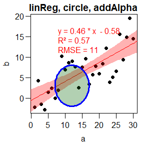

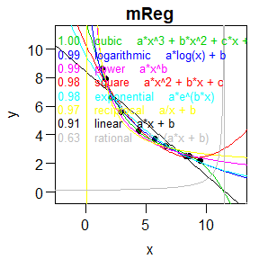

Table with numbers and corresponding color: `tableColVal`

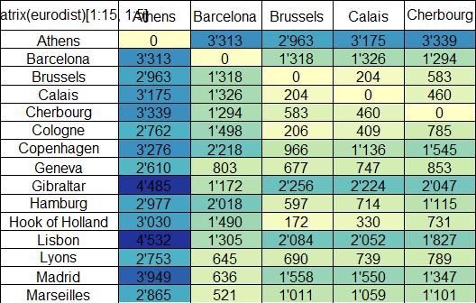

```r
tableColVal(as.matrix(eurodist)[1:15,1:5], nameswidth=0.25)
```

Climate diagram: `climateGraph`

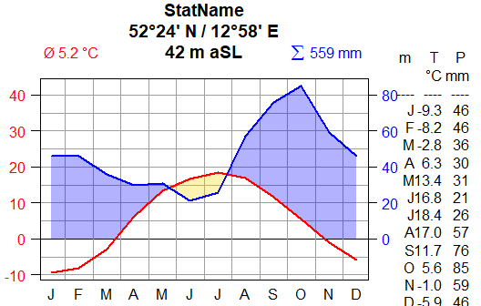

```r
climateGraph(temp=c(-9.3,-8.2,-2.8,6.3,13.4,16.8,18.4,17,11.7,5.6,-1,-5.9),
             rain=c(46,46,36,30,31,21,26,57,76,85,59,46))
```

TOC

## Dataframe Operations

```r
# Convert list with vectors of unequal length to one single data.frame: l2df
eglist <- list(AB=c(6,9,2,6), CD=1:8, EF=c(-3,2) )
eglist
```

```
## $AB
## [1] 6 9 2 6
##
## $CD
## [1] 1 2 3 4 5 6 7 8
##
## $EF
## [1] -3  2
```

```r
l2df(eglist)  # names are even kept
```

```
##    V1 V2 V3 V4 V5 V6 V7 V8
## AB  6  9  2  6 NA NA NA NA
## CD  1  2  3  4  5  6  7  8
## EF -3  2 NA NA NA NA NA NA
```

```r
# add rows to a data.frame: addRows, insertRows
MYDF <- data.frame(A=5:3, B=2:4)
addRows(MYDF, 3)
```

```
##    A  B
## 1  5  2
## 2  4  3
## 3  3  4
## 4 NA NA
## 5 NA NA
## 6 NA NA
```

```r
insertRows(MYDF, 2, 10:11)
```

```
##    A  B
## 1  5  2
## 2 10 11
## 3  4  3
## 4  3  4
```

```r
# Order rows in a dataframe: sortDF
sortDF(USArrests[USArrests$Murder>14,], "Assault", decreasing=TRUE)
```

```
##                Murder Assault UrbanPop Rape
## Florida          15.4     335       80 31.9
## South Carolina   14.4     279       48 22.5
## Mississippi      16.1     259       44 17.1
## Louisiana        15.4     249       66 22.2
## Georgia          17.4     211       60 25.8
```

```r
# truth table to test logical expressions: TFtest
TFtest(!a & !b, a&b, !(a&b))
```

```
##       a     b __ !a & !b __ a & b __ !(a & b)
## 1  TRUE  TRUE      FALSE     TRUE       FALSE
## 2  TRUE FALSE      FALSE    FALSE        TRUE
## 3  TRUE    NA      FALSE       NA          NA
## 4 FALSE  TRUE      FALSE    FALSE        TRUE
## 5 FALSE FALSE       TRUE    FALSE        TRUE
## 6 FALSE    NA         NA    FALSE        TRUE
## 7    NA  TRUE      FALSE       NA          NA
## 8    NA FALSE         NA    FALSE        TRUE
## 9    NA    NA         NA       NA          NA
```

```r
# Head and tail at the same time: headtail (exception from lowerCamelCasing)
headtail(iris, n=3, na=FALSE)
```

```
##     Sepal.Length Sepal.Width Petal.Length Petal.Width   Species
## 1            5.1         3.5          1.4         0.2    setosa
## 2            4.9         3.0          1.4         0.2    setosa
## 3            4.7         3.2          1.3         0.2    setosa
## 148          6.5         3.0          5.2         2.0 virginica
## 149          6.2         3.4          5.4         2.3 virginica
## 150          5.9         3.0          5.1         1.8 virginica
```

TOC

## Graphics

Color palettes: `seqPal`, `divPal`, `showPal`  
Plot simulation results as result ranges: `quantileBands`, `ciBand`

```r
showPal(cex=3)

neff <- t(replicate(n=300, sapply(1:200, function(nn) max(rnorm(nn)))   ))
qB <- quantileBands(neff, x=1:200, smooth=7)
```

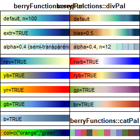

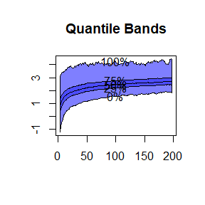

Quickly plot distributions by just specifying parameters: `normPlot`, `betaPlot`

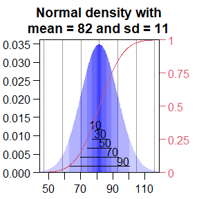

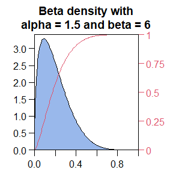

```r
normPlot(mean=81.7, sd=11.45)
betaPlot(shape1=1.5, shape2=6)
```

Compare Beta distribution parameter effects: `betaPlotComp`

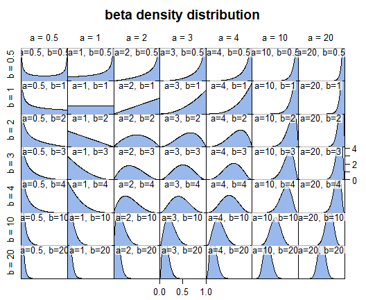

```r
betaPlotComp()
```

Set ylim so that it does not extend below zero: `lim0`

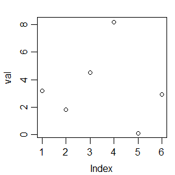

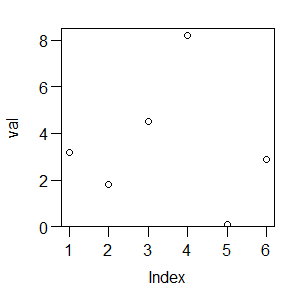

```r
val <- c(3.2, 1.8, 4.5, 8.2, 0.1, 2.9) # just some numbers
plot(val) # axes are extended by 4\% automatically, if xaxs="r"
plot(val, ylim=lim0(val), las=1) # you don't even have to set yaxs="i" ;-)
```

Histogram with bars drawn horizontally: `horizHist`  
Histograms for dataset split into categories: `groupHist`  
(Uses `panelDim` to compute layout of panels passed to `par(mfrow)`)

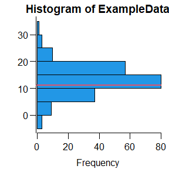

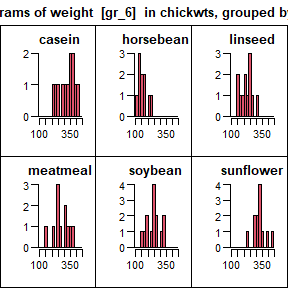

```r
ExampleData <- rnorm(200,13,5)
hpos <- horizHist(ExampleData, col=4)
abline(h=hpos(11), col=2, lwd=2)

groupHist(chickwts, "weight", "feed", col=2, unit="gr_6")
# drop the horsebean, feed those chicks with sunflower seeds (unless you like small chicken)
```

A few interactive things (not shown als Graphs)  
Zoom into graphics: `pointZooom`  
Horizontal and Vertial line at point clicked on: `locLine`  
Transformation from linear to logarithmic axis: `linLogHist`, `linLogTrans`

```r
a <- rnorm(90); b <- rexp(90)
dev.new(record=TRUE) # turn recording on
plot(a,b, las=1)
pointZoom(a,b) # scroll through the plots (Pg Up and Pg Dn) to unzoom again.

locLine()

x <- rlnorm(700, m=3)
dev.new(record=TRUE) # scroll through the plots (Pg Up and Pg Dn)...
linLogHist(x, xlab="ddd", breaks=30, yaxt="n", freq=FALSE)
```

Moving average with overlapping windows: `movAv`, `movAvLines`  
Funnel plot for proportional Data: `funnelPlot`

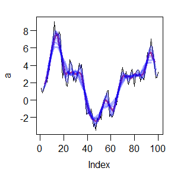

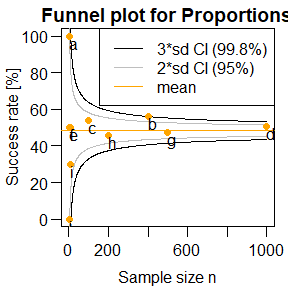

```r
plot(a, type="l", pch=16, las=1)
lines(movAv(a), col=2, lwd=3)
movAvLines(y=a, lwd=3)

X <- c(2, 224,  54,  505, 1,  5, 236,  92,  3, 0) # successful events
N <- c(2, 400, 100, 1000, 2, 10, 500, 200, 10, 2) # possible succeses
funnelPlot(X,N, letters[1:10])
```

Get nice values and labels to write at logarithmic axes: `logVals`, `logAxis`  
Label time axis in date-regular intervals: `monthLabs`, `monthAxis`

```
## List of 4
##  $ mlabs: Date[1:18], format: "2013-04-15" "2013-05-15" ...
##  $ ylabs: Date[1:2], format: "2013-08-18" "2014-05-15"
##  $ mtics: Date[1:19], format: "2013-04-01" "2013-05-01" ...
##  $ ytics: Date[1:1], format: "2014-01-01"
```

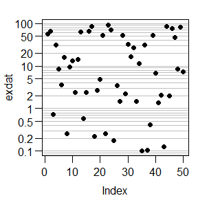

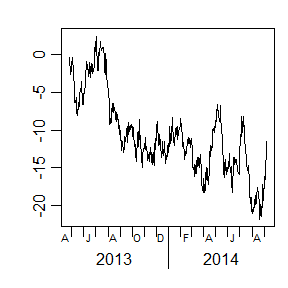

```r
exdat <- 10^runif(50, -1, 2)
plot(exdat, log="y", yaxt="n")
logAxis(side=2) # invisibly returns values and labels
points(exdat, pch=16)

plot(as.Date("2013-04-25")+0:500, cumsum(rnorm(501)), type="l", xaxt="n", ann=FALSE)
dummy <- monthAxis(side=1)
str(dummy)
```

TOC

## Hydrology

Extreme value Statistics (e.g. for flood risk estimation): moved to https://github.com/brry/extremeStat

```r
# superposition of precipitation to simulate Q from P: superPos
N <- c(9,5,2,14,1,3) # [mm/hour]
UH <- c(0.1, 0.4, 0.3, 0.1, 0.1) # [1/h]
superPos(N, UH)
```

```
##  [1] 0.9 4.1 4.9 4.6 7.7 5.6 3.1 2.4 0.4 0.3
```

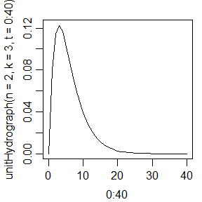

```r
# calculate continuous UH with given n and k: unitHydrograph
plot(0:40, unitHydrograph(n=2,  k=3, t=0:40), type="l")
```

```r
# Nash-Sutcliffe and kling-gupta efficiency: nse + kge
QSIM <- lsc(PREC, QOBS, area=10, returnsim=TRUE, plot=FALSE)
nse(QOBS, QSIM)
```

```
## [1] 0.8652
```

```r
kge(QOBS, QSIM)
```

```
## [1] 0.88685
```

```r
# Root Mean Squared Error, e.g. to be minimized: rmse
rmse(QOBS, QSIM)
```

```
## [1] 0.38461
```

```r
# R squared (coefficient of determination): rsquare
rsquare(QOBS, QSIM)
```

```
## [1] 0.89574
```

TOC

## Programming

`tmessage`, `twarning`, `tstop`: explicit tracing of messages, warnings and errors:

```r
lower <- function(a, s) {tmessage("some stuff with ", a+10, skip=s); a}
upper <- function(b, skip=0) lower(b+5, skip)
upper(3)
```

```
## tools::buildVignettes -> knitr::knit -> process_file -> handle_error -> process_group -> process_group.block -> call_block -> block_exec ->  upper -> lower: some stuff with 18
```

```
## [1] 8
```

`tryStack`: tracing any message / warning error in other people’s code, can also log to a file:

```
## printing c: 42
```

```
## Message: fake message, a = 42
## -- tryStack sys.calls: tools::buildVignettes -> engine$weave -> vweave_rmarkdown -> rmarkdown::render -> knitr::knit -> process_file -> handle_error -> withCallingHandlers -> withCallingHandlers -> process_group -> process_group.block -> call_block -> block_exec -> eng_r -> in_input_dir -> in_dir…
```

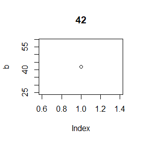

```
## tryStack error in a + 10: non-numeric argument to binary operator
## -- tryStack sys.calls: tools::buildVignettes -> engine$weave -> vweave_rmarkdown -> rmarkdown::render -> knitr::knit -> process_file -> handle_error -> withCallingHandlers -> withCallingHandlers -> process_group -> process_group.block -> call_block -> block_exec -> eng_r -> in_input_dir -> in_dir…
```

```r
lower <- function(a) {message("fake message, a = ", a); a+10}
middle <- function(b) {plot(b, main=b) ; warning("fake warning, b = ", b); lower(b) }
upper <- function(c) {cat("printing c:", c, "\n") ; middle(c)}
tryStack(upper("42") )
```

TOC

## Miscellaneous

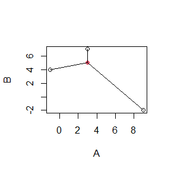

```r
# distance between two points on a plane: distance
A <- c(3,  9,-1)  ;  B <- c(7, -2, 4)
plot(A,B); points(3,5, col=2, pch=16); segments(3,5, A,B)
```

```r
distance(A,B, 3,5)
```

```
## [1] 2.0000 9.2195 4.1231
```

```r
# remove leading and trailing white space: removeSpace
s <- c("space at end     ", "  white at begin", "  both ", " special ^  ")
removeSpace(s)
```

```
## [1] "space at end"   "white at begin" "both"           "special ^"
```

```r
# sequence given by range or vector of values: seqR
seqR(range=c(12,6), by=-2)
```

```
## [1] 12 10  8  6
```

```r
seqR(rnorm(20), len=7)
```

```
## [1] -1.90100 -1.31629 -0.73159 -0.14688  0.43782  1.02253  1.60723
```

```r
# Rescale values to another range: rescale
rescale(10:15, from=200, to=135)
```

```
## [1] 200 187 174 161 148 135
```

```r
# Show memory size of the biggest objects in MB: lsMem
lsMem(n=5)
```

```
##      neff       dat        qB      hpos    middle sum rest:
##  0.480216  0.079832  0.020992  0.007472  0.007024  0.022184
```

```r
# extract pdf link from google search result url: googleLink2pdf
Link <- paste0("http://www.google.de/url?sa=t&rct=j&q=&esrc=s&source=web&cd=1",
        "&cad=rja&sqi=2&ved=0CDIQFjAA&url=http%3A%2F%2Fcran.r-project.org",
        "%2Fdoc%2Fmanuals%2FR-intro.pdf&ei=Nyl4UfHeOIXCswa6pIC4CA",
        "&usg=AFQjCNGejDwPlor4togQZmQEQv72cK9z8A&bvm=bv.45580626,d.Yms")
googleLink2pdf(Link)
```

```
## [1] "http://cran.r-project.org/doc/manuals/R-intro.pdf"
```

```r
# Create a number of 999 strings with spaces for reading files: na9
na9()[c(1:4,13,30)]
```

```
## [1] "-9999"     "-999"      "-9,99"     "-9,999"    "-999,0000" " -999"
```

A few things not executed for this document:

```r
# Separate lists with arguments for functions: owa
?owa # the example section has a good - wait for it - example!

# install.package and require in one single function: require2
require2(ada)

# Write a file with a Roxygen-compatible function structure,
# making it easy to add new functions to the package: createFun
createFun(myNewFunction, package="extremeStat", path="S:/Dropbox")

# Open the source code of a function on github: funSource
funSource("smoothLines")

# Install a package from github without dependencies: instGit
instGit("brry/shapeInteractive")


# concatenate textfiles contents unchanged into one file: combineFiles
# see also: compareFiles, dupes
cat("This is Sparta.\nKicking your face.", file="BujakashaBerry1.txt")
cat("Chuck Norris will roundhousekick you.", file="BujakashaBerry2.txt")
combineFiles(inFiles=paste0("BujakashaBerry", 1:2, ".txt"),
                 outFile="BujakashaBerry3.txt")
readLines("BujakashaBerry3.txt")
unlink(paste0("BujakashaBerry", 1:3, ".txt"))

# wish neRds a happy new year: yearSample
yearSample(2016)
# Have a nerdy
set.seed(12353); sample(0:9,4,T)

# generate name from "random" sample: nameSample
nameSample("berry")
```

```r
# Kind regards from
set.seed(8833277); paste(sample(letters,5,rep=T),collapse='')
```

```
## [1] "berry"
```

TOC

Explore the other possibilities of the package by reading the function help files.  
Any Feedback on this package (or this vignette) is very welcome via github or berry-b@gmx.de!